# Project Python Foundations: FoodHub Data Analysis

### Context

The number of restaurants in New York is increasing day by day. Lots of students and busy professionals rely on those restaurants due to their hectic lifestyles. Online food delivery service is a great option for them. It provides them with good food from their favorite restaurants. A food aggregator company FoodHub offers access to multiple restaurants through a single smartphone app.

The app allows the restaurants to receive a direct online order from a customer. The app assigns a delivery person from the company to pick up the order after it is confirmed by the restaurant. The delivery person then uses the map to reach the restaurant and waits for the food package. Once the food package is handed over to the delivery person, he/she confirms the pick-up in the app and travels to the customer's location to deliver the food. The delivery person confirms the drop-off in the app after delivering the food package to the customer. The customer can rate the order in the app. The food aggregator earns money by collecting a fixed margin of the delivery order from the restaurants.

### Objective

The food aggregator company has stored the data of the different orders made by the registered customers in their online portal. They want to analyze the data to get a fair idea about the demand of different restaurants which will help them in enhancing their customer experience. Suppose you are hired as a Data Scientist in this company and the Data Science team has shared some of the key questions that need to be answered. Perform the data analysis to find answers to these questions that will help the company to improve the business.

### Data Description

The data contains the different data related to a food order. The detailed data dictionary is given below.

### Data Dictionary

- order_id: Unique ID of the order
- customer_id: ID of the customer who ordered the food
- restaurant_name: Name of the restaurant
- cuisine_type: Cuisine ordered by the customer
- cost_of_the_order: Cost of the order
- day_of_the_week: Indicates whether the order is placed on a weekday or weekend (The weekday is from Monday to Friday and the weekend is Saturday and Sunday)
- rating: Rating given by the customer out of 5
- food_preparation_time: Time (in minutes) taken by the restaurant to prepare the food. This is calculated by taking the difference between the timestamps of the restaurant's order confirmation and the delivery person's pick-up confirmation.
- delivery_time: Time (in minutes) taken by the delivery person to deliver the food package. This is calculated by taking the difference between the timestamps of the delivery person's pick-up confirmation and drop-off information

### Let us start by importing the required libraries

```python
# import libraries for data manipulation
import numpy as np
import pandas as pd

# import libraries for data visualization
import matplotlib.pyplot as plt
import seaborn as sns

pd.set_option('display.float_format',lambda x:'%.3f' %x)
%matplotlib inline
```

### Understanding the structure of the data

```python
from google.colab import drive
drive.mount('/content/drive')
```

```python
# Reading the data
project_path = '/content/drive/MyDrive/Colab Notebooks/University Case Studies/Project 1/'
notebook_name = 'foodhub_order.csv'
path = project_path + notebook_name
data = pd.read_csv(path)

# Make a copy of the data, so we can keep the original one
df=data.copy()
```

```python
# View the first 5 rows
df.head(5)
```

|  | order_id | customer_id | restaurant_name | cuisine_type | cost_of_the_order | day_of_the_week | rating | food_preparation_time | delivery_time |
| --- | --- | --- | --- | --- | --- | --- | --- | --- | --- |
| 0 | 1477147 | 337525 | Hangawi | Korean | 30.750 | Weekend | Not given | 25 | 20 |
| 1 | 1477685 | 358141 | Blue Ribbon Sushi Izakaya | Japanese | 12.080 | Weekend | Not given | 25 | 23 |
| 2 | 1477070 | 66393 | Cafe Habana | Mexican | 12.230 | Weekday | 5 | 23 | 28 |
| 3 | 1477334 | 106968 | Blue Ribbon Fried Chicken | American | 29.200 | Weekend | 3 | 25 | 15 |
| 4 | 1478249 | 76942 | Dirty Bird to Go | American | 11.590 | Weekday | 4 | 25 | 24 |

### **Question 1:** How many rows and columns are present in the data? [0.5 mark]

```python
# Checking the shape of our data
df.shape
```

```
(1898, 9)
```

#### Observations:

In the food dataset there are 1898 rows and 9 columns.

### **Question 2:** What are the datatypes of the different columns in the dataset? (The info() function can be used) [0.5 mark]

```python
df.info();
```

```
<class 'pandas.core.frame.DataFrame'>
RangeIndex: 1898 entries, 0 to 1897
Data columns (total 9 columns):
 #   Column                 Non-Null Count  Dtype
---  ------                 --------------  -----
 0   order_id               1898 non-null   int64
 1   customer_id            1898 non-null   int64
 2   restaurant_name        1898 non-null   object
 3   cuisine_type           1898 non-null   object
 4   cost_of_the_order      1898 non-null   float64
 5   day_of_the_week        1898 non-null   object
 6   rating                 1898 non-null   object
 7   food_preparation_time  1898 non-null   int64
 8   delivery_time          1898 non-null   int64
dtypes: float64(1), int64(4), object(4)
memory usage: 133.6+ KB
```

```python
# Change data types of customer id and order id to string for better analysys result in the future
df['customer_id'] = df['customer_id'].astype('string')
df['order_id'] = df['order_id'].astype('string')
```

#### Observations:

There some different data types:

- int64
- float64
- object(string)

As we can see the raitng is object, we can deep dive into it

### **Question 3:** Are there any missing values in the data? If yes, treat them using an appropriate method. [1 mark]

```python
print('The number of missing values in the dataset:\n',df.isna().sum())
print('\nThe unique values of Rating: ',df['rating'].unique())
```

```
The number of missing values in the dataset:
 order_id                 0
customer_id              0
restaurant_name          0
cuisine_type             0
cost_of_the_order        0
day_of_the_week          0
rating                   0
food_preparation_time    0
delivery_time            0
dtype: int64

The unique values of Rating:  ['Not given' '5' '3' '4']
```

#### Observations:

There is no missing values, but the rating has Not given value, we can replace it with NaN or keep it as separate category. Because I want to do more analysis on it, I will keep it as a separate category

### **Question 4:** Check the statistical summary of the data. What is the minimum, average, and maximum time it takes for food to be prepared once an order is placed? [2 marks]

```python
df.describe().T
```

|  | count | mean | std | min | 25% | 50% | 75% | max |
| --- | --- | --- | --- | --- | --- | --- | --- | --- |
| cost_of_the_order | 1898.000 | 16.499 | 7.484 | 4.470 | 12.080 | 14.140 | 22.297 | 35.410 |
| food_preparation_time | 1898.000 | 27.372 | 4.632 | 20.000 | 23.000 | 27.000 | 31.000 | 35.000 |
| delivery_time | 1898.000 | 24.162 | 4.973 | 15.000 | 20.000 | 25.000 | 28.000 | 33.000 |

#### Observations:

As we can see from the statistical summary provided by describe function, the minimum, average, and maximum time it takes for food to be prepared once an order is placed are:

- Min: 20 min
- Max: 35 min
- Average: 27.37 min

### **Question 5:** How many orders are not rated? [1 mark]

```python
print('The unique valuse for rating that we have: ',df['rating'].unique())
not_rated_orders = df['rating'].value_counts()['Not given']
print('The number of orders that are not rated: ',not_rated_orders)
```

```
The unique valuse for rating that we have:  ['Not given' '5' '3' '4']
The number of orders that are not rated:  736
```

#### Observations:

To find the ratings values in our dataset, at first we use the unique function on our rating column and from that we can see we have 'Not given' for not rated orders.

Then based on it we can find that we have 736 orders that don't have any rating

### Exploratory Data Analysis (EDA)

### **Question 6:** Explore all the variables and provide observations on their distributions. (Generally, histograms, boxplots, countplots, etc. are used for univariate exploration.) [9 marks]

#### Explor the **unique values**

Before any analysis I want to check the unique values and the count oof them for each feature

```python
unique_cid = df['customer_id'].nunique()
unique_rn = df['restaurant_name'].nunique()
unique_rn_list = df['restaurant_name'].unique()
unique_oid = df['order_id'].nunique()
unique_ct = df['cuisine_type'].nunique()
unique_ct_list = df['cuisine_type'].unique()
unique_day = df['day_of_the_week'].nunique()
unique_day_list = df['day_of_the_week'].unique()
unique_rating = df['rating'].nunique()
unique_rating_list = df['rating'].unique()

print(f'There are {unique_cid} unique customer ids')
print(f'\nThere are {unique_rn} unique restaurant names')
print('\nThe unique restaurant names are:\n',unique_rn_list)
print(f'\nThere are {unique_oid} unique order ids')
print(f'\nThere are {unique_ct} unique cuisine types')
print('\nThe unique cuisine types are:\n',unique_ct_list)
print(f'\nThere are {unique_day} unique days of the week')
print('\nThe unique days of the week are: ',unique_day_list)
print(f'\nThere are {unique_rating} unique ratings')
print('\nThe unique ratings are: ',unique_rating_list)
```

```
There are 1200 unique customer ids

There are 178 unique restaurant names

The unique restaurant names are:
 ['Hangawi' 'Blue Ribbon Sushi Izakaya' 'Cafe Habana'
 'Blue Ribbon Fried Chicken' 'Dirty Bird to Go' 'Tamarind TriBeCa'
 'The Meatball Shop' 'Barbounia' 'Anjappar Chettinad' 'Bukhara Grill'
 'Big Wong Restaurant \x8c_¤¾Ñ¼' 'Empanada Mama (closed)' 'Pylos'
 "Lucky's Famous Burgers" 'Shake Shack' 'Sushi of Gari' 'RedFarm Hudson'
 'Blue Ribbon Sushi' 'Five Guys Burgers and Fries' 'Tortaria'
 'Cafe Mogador' 'Otto Enoteca Pizzeria' 'Vezzo Thin Crust Pizza'
 'Sushi of Gari 46' 'The Kati Roll Company' 'Klong' '5 Napkin Burger'
 'TAO' 'Parm' 'Sushi Samba' 'Haru Gramercy Park'
 'Chipotle Mexican Grill $1.99 Delivery' 'RedFarm Broadway' 'Cafeteria'
 'DuMont Burger' "Sarabeth's East" 'Hill Country Fried Chicken' 'Bistango'
 "Jack's Wife Freda" "Mamoun's Falafel" 'Prosperity Dumpling'
 'Blue Ribbon Sushi Bar & Grill' 'Westville Hudson' 'Blue Ribbon Brooklyn'
 'Nobu Next Door' 'Osteria Morini' 'Haandi' 'Benihana' 'Han Dynasty'
 'Chote Nawab' 'Mission Cantina' "Xi'an Famous Foods" 'Rubirosa'
 "Joe's Shanghai \x8e_À\x8eü£¾÷´" 'Bareburger' 'The Odeon' 'Pongsri Thai'
 'Yama Japanese Restaurant' 'Momoya' 'Balthazar Boulangerie' 'CafÌ© China'
 'Boqueria' 'Song Thai Restaurant & Bar' 'Five Leaves'
 'Pinto Nouveau Thai Bistro' "Amy Ruth's" 'Pepe Giallo' 'indikitch'
 'Yama 49' 'Piccolo Angolo' 'Pepe Rosso To Go' "L'Express" 'Amma'
 'Delicatessen' "S'MAC" "Vanessa's Dumplings" 'Bhatti Indian Grill'
 'Taro Sushi' 'Donburi-ya' 'Hatsuhana' 'Samurai Mama' 'Waverly Diner'
 'Tarallucci e Vino Restaurant' "P.J. Clarke's" 'Lantern Thai Kitchen'
 'ilili Restaurant' 'The Smile' "Vanessa's Dumpling House" "Bubby's "
 'Woorijip' 'Dirty Bird To Go (archived)' 'Haveli Indian Restaurant'
 'Dos Caminos' 'da Umberto' 'Sushi of Gari Tribeca' 'Burger Joint'
 'Room Service' "Sarabeth's Restaurant" 'Xe May Sandwich Shop' 'Hibino'
 'Mira Sushi' 'Melt Shop' 'J. G. Melon' 'Hummus Place' 'Saravanaa Bhavan'
 'Friend of a Farmer' 'The Loop' 'Balade' 'Posto' 'Terakawa Ramen'
 'Kambi Ramen House' 'Wo Hop Restaurant' 'Spice Thai'
 "Dickson's Farmstand Meats" 'UVA Wine Bar & Restaurant'
 'Serafina Fabulous Pizza' 'Gaia Italian Cafe'
 'Chola Eclectic Indian Cuisine' 'Hot Kitchen' 'Junoon'
 'Ravagh Persian Grill' 'Rohm Thai' 'Dig Inn Seasonal Market' 'Olea'
 'Cho Dang Gol' 'El Parador Cafe' 'Socarrat Paella Bar'
```

[output cut: 15 more lines]

```

There are 14 unique cuisine types

The unique cuisine types are:
 ['Korean' 'Japanese' 'Mexican' 'American' 'Indian' 'Italian'
 'Mediterranean' 'Chinese' 'Middle Eastern' 'Thai' 'Southern' 'French'
 'Spanish' 'Vietnamese']

There are 2 unique days of the week

The unique days of the week are:  ['Weekend' 'Weekday']

There are 4 unique ratings

The unique ratings are:  ['Not given' '5' '3' '4']
```

#### Explore **cost_of_the_order**

At first with the help of describe we have a quick look at the values and statistics, then we will plot the histogram and box plot

```python
df['cost_of_the_order'].describe()
```

|  | cost_of_the_order |
| --- | --- |
| count | 1898.000 |
| mean | 16.499 |
| std | 7.484 |
| min | 4.470 |
| 25% | 12.080 |
| 50% | 14.140 |
| 75% | 22.297 |
| max | 35.410 |

**dtype:** float64

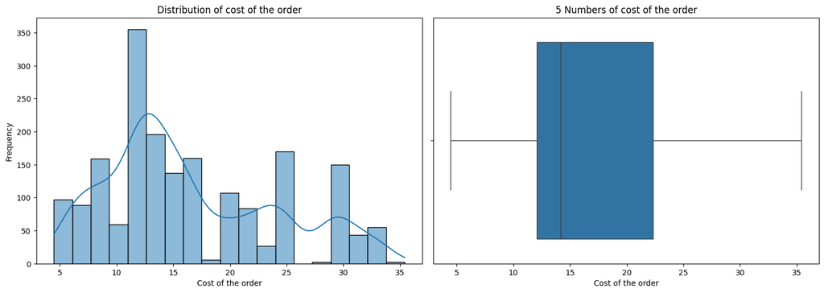

```python
plt.figure(figsize=(15, 10))

# Make 2 columns to show the plots side by side
plt.subplot(2,2,1)

# Histogram
sns.histplot(
    data=df,
    x='cost_of_the_order',
    kde=True);

plt.xlabel('Cost of the order');
plt.ylabel('Frequency');
plt.title('Distribution of cost of the order');

# Second column
plt.subplot(2,2,2)

# Box Plot
sns.boxplot(data=df,
            x='cost_of_the_order');

plt.xlabel('Cost of the order');
plt.title('5 Numbers of cost of the order');

# Showing the plots
plt.tight_layout()
plt.show()
```

##### **Observations:**

- The mean cost of the orders is 16.499 dollar, and the median is slightly lower at 14.140 dollar, indicating a slight right skew.
- The distribution shows a multimodal data.
- There is a reasonable spread in the data, with most orders clustered around 12 to 23 dollar.
- The box plot doesn't show any outliers.
- The distribution is right-skewed, meaning there are more low-cost orders than high-cost ones.

#### Explor the **food_preparation_time**

At first with the help of describe we have a quick look at the values and statistics, then we will plot the histogram and box plot

```python
df['food_preparation_time'].describe()
```

|  | food_preparation_time |
| --- | --- |
| count | 1898.000 |
| mean | 27.372 |
| std | 4.632 |
| min | 20.000 |
| 25% | 23.000 |
| 50% | 27.000 |
| 75% | 31.000 |
| max | 35.000 |

**dtype:** float64

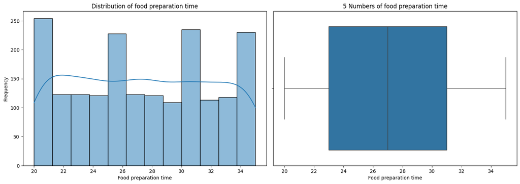

```python
plt.figure(figsize=(15, 10))

# Make 2 columns to show the plots side by side
plt.subplot(2,2,1)

#Histogram
sns.histplot(
    data=df,
    x='food_preparation_time',
    kde=True);

plt.xlabel('Food preparation time');
plt.ylabel('Frequency');
plt.title('Distribution of food preparation time');

# Second column
plt.subplot(2,2,2)

# Box Plot
sns.boxplot(data=df,
            x='food_preparation_time');

plt.xlabel('Food preparation time');
plt.title('5 Numbers of food preparation time');

# Showing the plots
plt.tight_layout()
plt.show()
```

**Observations:**

- Range of Values:

The food preparation time ranges from approximately 20 to 35 minutes, with intervals between 20-22, 22-24, etc.

#### Explore the **delivery_time**

At first with the help of describe we have a quick look at the values and statistics,after that a quick look at all delivery times and their frequency, then we will plot the histogram and box plot

```python
df['delivery_time'].describe()
```

|  | delivery_time |
| --- | --- |
| count | 1898.000 |
| mean | 24.162 |
| std | 4.973 |
| min | 15.000 |
| 25% | 20.000 |
| 50% | 25.000 |
| 75% | 28.000 |
| max | 33.000 |

**dtype:** float64

```python
df['delivery_time'].value_counts().sort_values(ascending=False)
```

| delivery_time | count |
| --- | --- |
| 24 | 162 |
| 28 | 148 |
| 29 | 148 |
| 26 | 141 |
| 27 | 138 |
| 30 | 133 |
| 25 | 120 |
| 19 | 90 |
| 16 | 90 |
| 20 | 88 |
| 15 | 87 |
| 22 | 85 |
| 18 | 83 |
| 21 | 81 |
| 17 | 78 |
| 23 | 77 |
| 32 | 59 |
| 33 | 49 |
| 31 | 41 |

**dtype:** int64

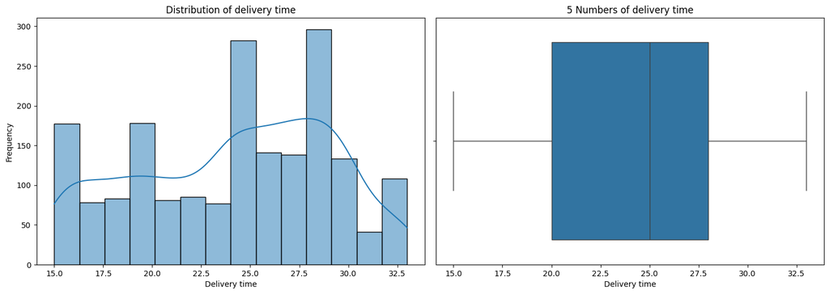

```python
plt.figure(figsize=(15, 10))

# Make 2 columns to show the plots side by side
plt.subplot(2,2,1)

sns.histplot(data=df,
             x='delivery_time',
             kde=True);

plt.xlabel('Delivery time');
plt.ylabel('Frequency');
plt.title('Distribution of delivery time');

# Second column
plt.subplot(2,2,2)

# Box Plot
sns.boxplot(data=df,
            x='delivery_time');

plt.xlabel('Delivery time');
plt.title('5 Numbers of delivery time');

# Showing the plots
plt.tight_layout()
plt.show()

plt.show();
```

**Observations:**

- The mean time of deliver the orders is 24.16 minutes, and the median is slightly upper at 25 dollar, indicating a slight left skew.
- The distribution shows a bimodal data arount 16-20 and 35-30. This indicates that food delivery times cluster around these two ranges.
- The box plot doesn't show any outliers.
- The distribution is left-skewed, meaning there are more long delivery time of orders than less-time ones.

#### Now let's check the **rating**.

At first with the help of describe we have a quick look at the values and statistics, then we will plot the bar plot and pie chart

```python
df['rating'].describe()
```

|  | rating |
| --- | --- |
| count | 1898 |
| unique | 4 |
| top | Not given |
| freq | 736 |

**dtype:** object

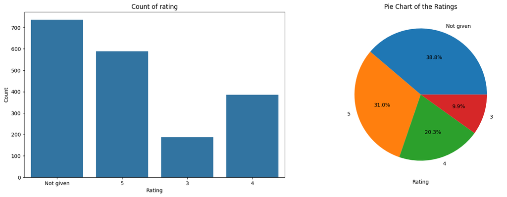

```python
plt.figure(figsize=(15, 10))

# Make 2 columns to show the plots side by side
plt.subplot(2,2,1)

#Bar Plot
sns.countplot(data=df,
              x='rating');

plt.xlabel('Rating');
plt.ylabel('Count');
plt.title('Count of rating');

# Second column
plt.subplot(2,2,2)

# Pie Chart
plt.pie(df['rating'].value_counts(),
        labels=df['rating'].value_counts().index,
        autopct='%1.1f%%');

plt.title('Pie Chart of the Ratings')
plt.xlabel('Rating')

# Showing the plots
plt.tight_layout()
plt.show()
```

**Observations:**

The most rating is Not given and then 5 with 31 percentage indicating that most customers not rate or giving positive ratings.

There are some raatings being 3 that are the lowest and we should check to see if we can improve something or not

The distribution is slightly skewed toward higher ratings, with the majority of ratings being 4 or 5 stars.

Approximately 39% of the ratings are missing, which needs to be addressed in further analysis.

We dont have any under 3 ratings, it seems users keen to rate if the food quality is good, we can deep dive into it

#### Time to check **day_of_week**

We will check the barplot and pie chart

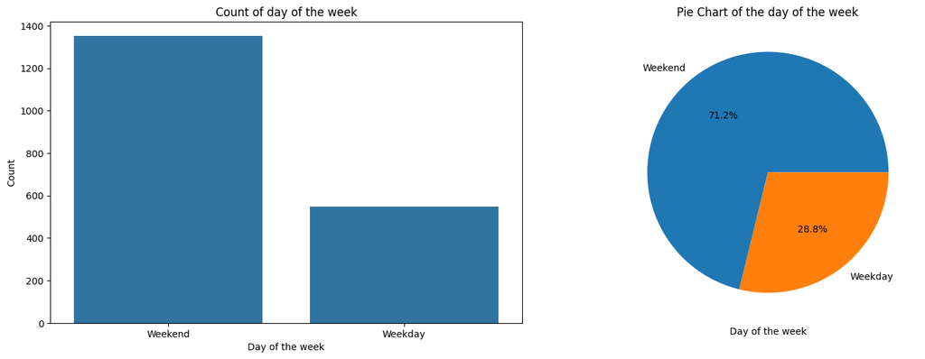

```python
plt.figure(figsize=(15, 10))

# Make 2 columns to show the plots side by side
plt.subplot(2,2,1)

#Bar Plot
sns.countplot(data=df,
              x='day_of_the_week');

plt.xlabel('Day of the week');
plt.ylabel('Count');
plt.title('Count of day of the week');

# Second column
plt.subplot(2,2,2)

# Pie Chart
plt.pie(df['day_of_the_week'].value_counts(),
        labels=df['day_of_the_week'].value_counts().index,
        autopct='%1.1f%%');

plt.title('Pie Chart of the day of the week')
plt.xlabel('Day of the week')

# Showing the plots
plt.tight_layout()
plt.show()
```

**Observations:**

#### Time to check **cuisine_type**

We will check the barplot and pie chart

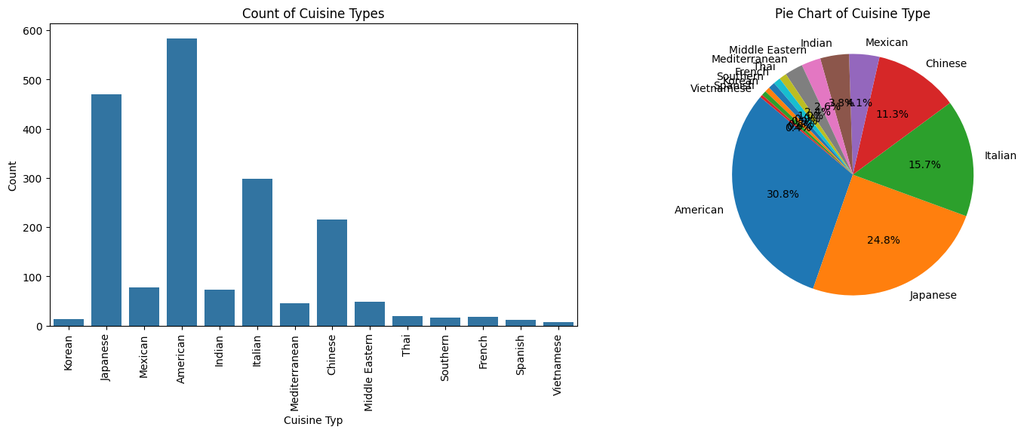

```python
plt.figure(figsize=(15, 10))

# Make 2 columns to show the plots side by side
plt.subplot(2,2,1)

#Bar Plot
sns.countplot(data=df,
              x='cuisine_type');

plt.xlabel('Cuisine Typ');
plt.ylabel('Count');
plt.title('Count of Cuisine Types');
plt.xticks(rotation=90);

# Second column
plt.subplot(2,2,2)

# Pie Chart
cuisine_counts = df['cuisine_type'].value_counts()

plt.pie(
    cuisine_counts,
    labels=cuisine_counts.index,
    autopct='%1.1f%%',
    startangle=140
)

plt.title("Pie Chart of Cuisine Type")

# Showing the plots
plt.tight_layout()
plt.show();
```

**Observation:**

As you can see the most ordered cusins are:

1. American
2. Japanese
3. Italian

We can check about the quality of other foods and the ratings and see if there is a way to improve it or not

#### **total_time**

Now lets add a new column to our dataset to check the time from start the order until it deliverd

```python
df['total_time'] = df['delivery_time'] + df['food_preparation_time']
df['total_time'].describe()
```

|  | total_time |
| --- | --- |
| count | 1898.000 |
| mean | 51.534 |
| std | 6.834 |
| min | 35.000 |
| 25% | 47.000 |
| 50% | 52.000 |
| 75% | 56.000 |
| max | 68.000 |

**dtype:** float64

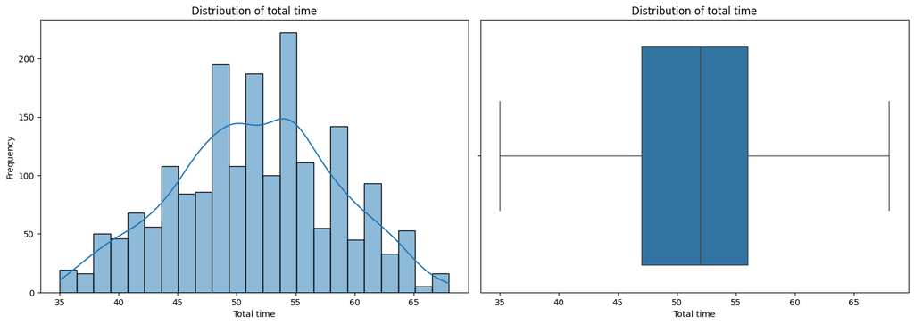

```python
plt.figure(figsize=(15, 10))

# Make 2 columns to show the plots side by side
plt.subplot(2,2,1)

sns.histplot(data=df,
             x='total_time',
             kde=True);

plt.xlabel('Total time');
plt.ylabel('Frequency');
plt.title('Distribution of total time');

# Second column
plt.subplot(2,2,2)

# Box Plot
sns.boxplot(data=df,
            x='total_time');

plt.xlabel('Total time');
plt.title('Distribution of total time');

# Showing the plots
plt.tight_layout()
plt.show()
```

**Observations:**

- Range of Values:

The food total time ranges from 35 to 68 minutes, with intervals between 35-40, 40-45, etc.

- Frequency Distribution:
  - There are notable peaks in the histogram at the intervals around 47-55 indicating this time range is more common.
- Shape of Distribution:
  - The histogram shows a somewhat bimodal distribution—it has two peaks, at approximately 47-52 and 52-57. This indicates that food times cluster around these two ranges.
  - There is no clear skewness, meaning the distribution is relatively symmetric, though it fluctuates with no smooth pattern between interval.
  - The box plot doesn't show any outliers.
  - There is a reasonable spread in the data, with most orders clustered around 47 to 57 minutes.

### **Question 7**: Which are the top 5 restaurants in terms of the number of orders received? [1 mark]

```python
# We can group our data by resturant name and the count the orders of each
df.groupby('restaurant_name')['order_id'].count().sort_values(ascending=False).head(5)
```

| restaurant_name | order_id |
| --- | --- |
| Shake Shack | 219 |
| The Meatball Shop | 132 |
| Blue Ribbon Sushi | 119 |
| Blue Ribbon Fried Chicken | 96 |
| Parm | 68 |

**dtype:** int64

#### Observations:

We can see that the top most resaurant are these with the highest of 219 order.

### **Question 8**: Which is the most popular cuisine on weekends? [1 mark]

Here we have 2 different ways to find the most popular one, by bar chart and by the code

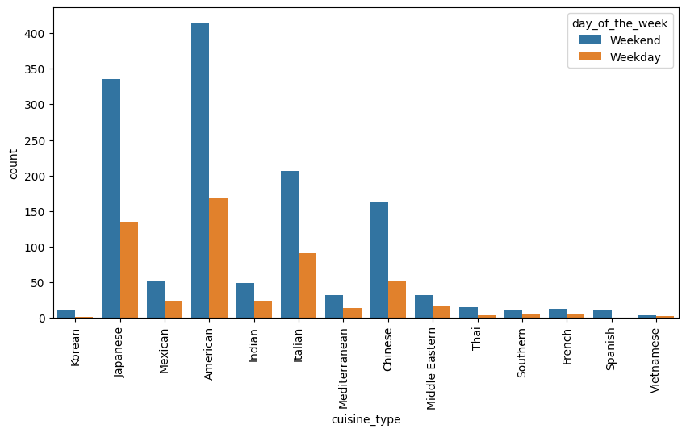

```python
# Bar plot solution
plt.figure(figsize=(10,5))

sns.countplot(data=df,
              x='cuisine_type',
              hue='day_of_the_week');

plt.xticks(rotation=90);
```

```python
# For the code solution we can group our data by day of the week and count the values of cuisine types
df.groupby('day_of_the_week')['cuisine_type'].value_counts().sort_values(ascending=False).head(5)

# Another solution
# group the data at first by day of the week and then by cuisine type and at the end, cout the orders
# df.groupby(['day_of_the_week','cuisine_type'])['order_id'].count().sort_values(ascending=False).head(5)
```

| day_of_the_week | cuisine_type | count |
| --- | --- | --- |
| Weekend | American | 415 |
|  | Japanese | 335 |
|  | Italian | 207 |
| Weekday | American | 169 |
| Weekend | Chinese | 163 |

**dtype:** int64

#### Observations:

From both the plot and the code we can see that American Cusins are the most popular one for the weekends

### **Question 9**: What percentage of the orders cost more than 20 dollars? [2 marks]

```python
# First we find the number of orders more than 20
condition = df['cost_of_the_order'] > 20
number_of_orders_more_than_20 = len(df[condition])
print('Number of orders that cost more than 20 dollars: ',number_of_orders_more_than_20)

# Now the number of all orders
number_of_all_orders = len(df)
print('Number of all orders: ',number_of_all_orders)

# Finally, the percentage of the orders more than 20
percentage_of_orders_more_than_20 = (number_of_orders_more_than_20 / number_of_all_orders) * 100
print(f'Percentage of the orders cost more than 20 dollars: {round(percentage_of_orders_more_than_20,2)}%')
```

```
Number of orders that cost more than 20 dollars:  555
Number of all orders:  1898
Percentage of the orders cost more than 20 dollars: 29.24%
```

#### Observations:

As we can see around 29% of orders cost more than 20 dollar

### **Question 10**: What is the mean order delivery time? [1 mark]

```python
# With mean function
mean_delivery_time = df['delivery_time'].mean()
print('The mean order delivery time is: ',round(mean_delivery_time,3))

# With describe function
#df['delivery_time'].describe()
```

```
The mean order delivery time is:  24.162
```

#### Observations:

As we can see the mean order delivery time is: 24.16

### **Question 11:** The company has decided to give 20% discount vouchers to the top 3 most frequent customers. Find the IDs of these customers and the number of orders they placed. [1 mark]

```python
# Simply we can count the number of customer ids
df['customer_id'].value_counts().sort_values(ascending=False).head(3)
```

| customer_id | count |
| --- | --- |
| 52832 | 13 |
| 47440 | 10 |
| 83287 | 9 |

**dtype:** Int64

#### Observations:

The user id with the most placed order is: 52832

### **Question 12**: Perform a multivariate analysis to explore relationships between the important variables in the dataset. (It is a good idea to explore relations between numerical variables as well as relations between numerical and categorical variables) [10 marks]

#### At first lets take a look at **heatmap**

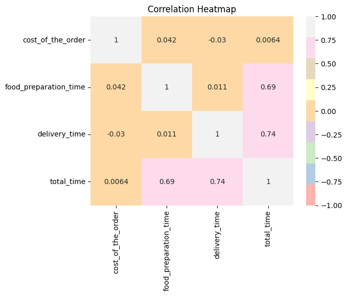

```python
# Find the correlation of numerical features
corr = df[['cost_of_the_order','food_preparation_time', 'delivery_time', 'total_time']].corr()

sns.heatmap(corr,
            annot=True,
            cmap='Pastel1',
            vmin=-1, vmax=1);

plt.title('Correlation Heatmap')
plt.show()
```

- The total time for an order is primarily influenced by both the delivery time and food preparation time, as indicated by the strong positive correlations with these variables.
- However, the cost of the order has minimal to no impact on time-related factors, implying that pricing decisions or order complexity are not driving factors in how long an order takes to fulfill.
- This information could help streamline operations by focusing on optimizing preparation and delivery times independently, without adjusting for order cost.

#### Lets check the relationship between the **price of orders** and the **days**

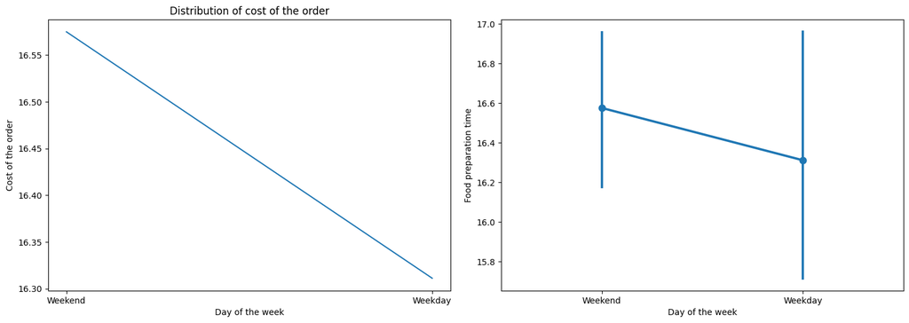

```python
plt.figure(figsize=(15, 10))

# Line plot
plt.subplot(2,2,1)
sns.lineplot(data=df,
             x='day_of_the_week',
             y='cost_of_the_order',
             errorbar=None);

plt.xlabel('Day of the week');
plt.ylabel('Cost of the order');
plt.title('Distribution of cost of the order');

# Ppint PLot
plt.subplot(2,2,2)
sns.pointplot(data=df,
              x='day_of_the_week',
              y='cost_of_the_order');

plt.xlabel('Day of the week');
plt.ylabel('Food preparation time');


# Showing the plots
plt.tight_layout()
plt.show()
```

#### Now let's check the relation between the **cuisine type** and the **price**

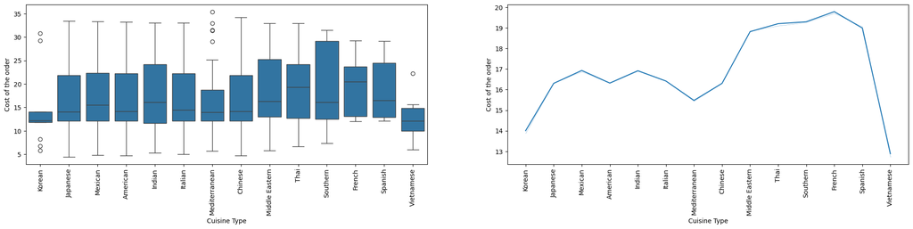

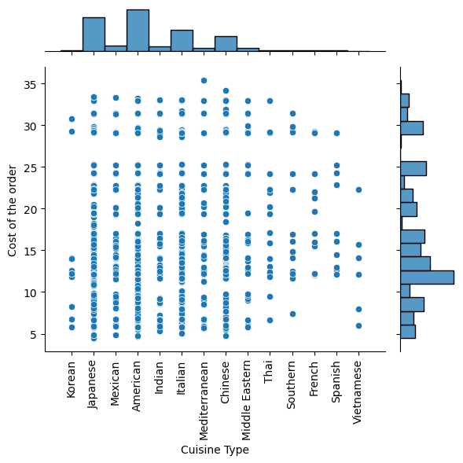

```python
plt.figure(figsize=(25, 10))

# Box plot
plt.subplot(2,2,1)
sns.boxplot(data=df,
             x='cuisine_type',
             y='cost_of_the_order');

plt.xlabel('Cuisine Type');
plt.ylabel('Cost of the order');
plt.xticks(rotation=90);

# Line PLot
plt.subplot(2,2,2)
sns.lineplot(data=df,
             x='cuisine_type',
             y='cost_of_the_order',
             errorbar=('ci',False),
             markers=True);

plt.xlabel('Cuisine Type');
plt.ylabel('Cost of the order');
plt.xticks(rotation=90);

# Join Plot
sns.jointplot(data=df,
              y='cost_of_the_order',
              x='cuisine_type');

plt.xlabel('Cuisine Type');
plt.ylabel('Cost of the order');
plt.xticks(rotation=90);


# Showing the plots
plt.tight_layout()
plt.show()
```

- Korean and Vietnamese cuisines tend to have lower and more consistent order costs, while Southern and Middle Eastern cuisines show greater variability and higher average costs.
- Common Price Range: Most orders, regardless of cuisine, tend to fall between $10 and $25, suggesting a standard pricing range for the majority of orders.
- Pricing Strategy: This data could be used to adjust pricing strategies based on cuisine type, optimizing for customer expectations and cost consistency.
- These insights can support menu pricing strategies, especially for cuisines with higher variability or outliers in order costs.

#### We can compare the **prepration time of the food** and the **cuisine type**

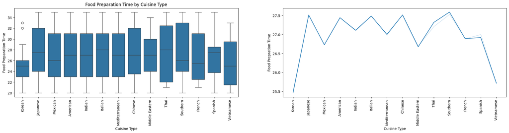

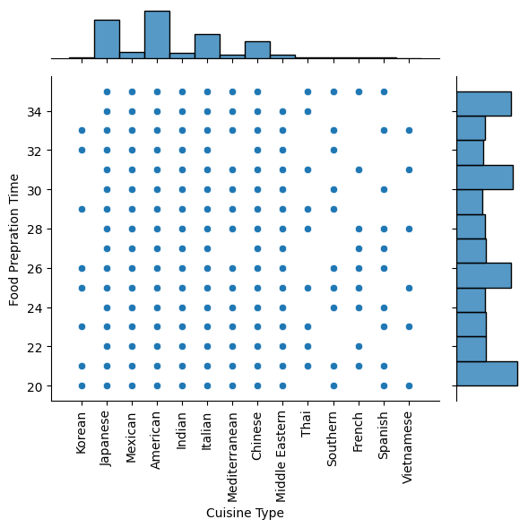

```python
plt.figure(figsize=(25, 10))

# Box plot
plt.subplot(2,2,1)
sns.boxplot(
    data=df,
    x='cuisine_type',
    y='food_preparation_time'
)

plt.title("Food Preparation Time by Cuisine Type")
plt.xlabel("Cuisine Type")
plt.ylabel("Food Preparation Time")
plt.xticks(rotation=90);

# Line PLot
plt.subplot(2,2,2)
sns.lineplot(data=df,
             x='cuisine_type',
             y='food_preparation_time',
             errorbar=('ci',False),
             markers=True);

plt.xlabel('Cuisine Type');
plt.ylabel('Food Prepration Time');
plt.xticks(rotation=90);

# Join Plot
sns.jointplot(data=df,
              y='food_preparation_time',
              x='cuisine_type');

plt.xlabel('Cuisine Type');
plt.ylabel('Food Prepration Time');
plt.xticks(rotation=90);


# Showing the plots
plt.tight_layout()
plt.show()
```

- As we can see the line is relatively stable with minor fluctuations, suggesting that while there are small differences in average preparation times, they are not dramatically different across cuisines.
- **Korean** food stands out with generally shorter preparation times and a few notable outliers, which could indicate efficiency or simpler preparation requirements.
- The box plot shows the range of food preparation times across different cuisines. Most cuisines have a similar interquartile range, centered around 22–30 minute

#### Aslo we can check to see which **resturant** is *fastest* for **preparing the food**

As we have a lot of resurants, let's check top 10 resturant and least 10 restaurant in receiving order

```python
# At first we group the restaurant by their name and count the orders
top_ordered_restaurants = df.groupby('restaurant_name')['order_id'].count().sort_values(ascending=False)

# Now finding top 10
top_10_restaurants = top_ordered_restaurants.head(10)

# Create DataFrame of top 10 for visualization
top_10_restaurants_index = top_10_restaurants.index
top_10_restaurants_df = df[df['restaurant_name'].isin(top_10_restaurants_index)]

print('Top 10 resturant in getting the order:\n', top_10_restaurants)

# Now finding least 10
least_10_restaurants = top_ordered_restaurants.tail(10)

# Create DataFrame of least 10 for visualization
least_10_restaurants_index = least_10_restaurants.index
least_10_restaurants_df = df[df['restaurant_name'].isin(least_10_restaurants_index)]

print('\nLeast 10 resturant in getting the order:\n', least_10_restaurants)
```

```
Top 10 resturant in getting the order:
 restaurant_name
Shake Shack                      219
The Meatball Shop                132
Blue Ribbon Sushi                119
Blue Ribbon Fried Chicken         96
Parm                              68
RedFarm Broadway                  59
RedFarm Hudson                    55
TAO                               49
Han Dynasty                       46
Blue Ribbon Sushi Bar & Grill     44
Name: order_id, dtype: int64

Least 10 resturant in getting the order:
 restaurant_name
Market Table               1
Lucky Strike               1
Le Zie 2000 Trattoria      1
La Follia                  1
Kori Restaurant and Bar    1
Klong                      1
Kambi Ramen House          1
Il Bambino                 1
Hunan Manor                1
Lamarca Pasta              1
Name: order_id, dtype: int64
```

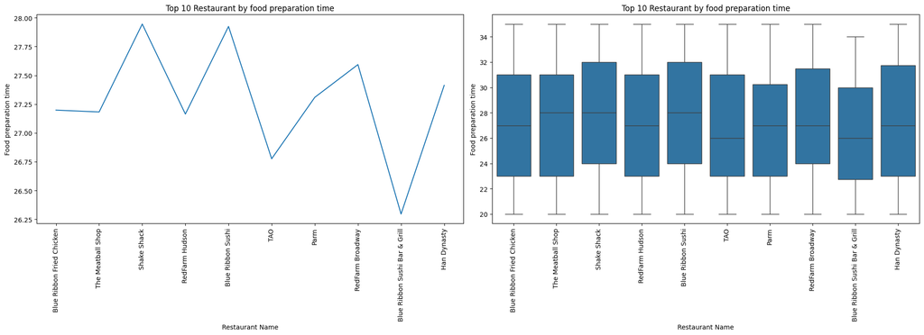

```python
plt.figure(figsize=(20, 12))

# Line plot
plt.subplot(2,2,1)
sns.lineplot(data=top_10_restaurants_df,
             x='restaurant_name',
             y='food_preparation_time',
             errorbar=None);

plt.xlabel('Restaurant Name');
plt.ylabel('Food preparation time');
plt.title('Top 10 Restaurant by food preparation time');
plt.xticks(rotation=90);

# Box plot
plt.subplot(2,2,2)
sns.boxplot(data=top_10_restaurants_df,
             x='restaurant_name',
             y='food_preparation_time');

plt.xlabel('Restaurant Name');
plt.ylabel('Food preparation time');
plt.title('Top 10 Restaurant by food preparation time');
plt.xticks(rotation=90);

# Showing the plots
plt.tight_layout()
plt.show()
```

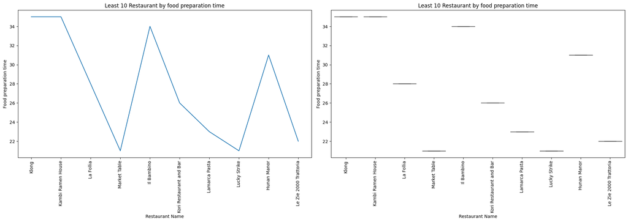

```python
plt.figure(figsize=(20, 12))

# Line plot
plt.subplot(2,2,1)
sns.lineplot(data=least_10_restaurants_df,
             x='restaurant_name',
             y='food_preparation_time',
             errorbar=None);

plt.xlabel('Restaurant Name');
plt.ylabel('Food preparation time');
plt.title('Least 10 Restaurant by food preparation time');
plt.xticks(rotation=90);

# Box plot
plt.subplot(2,2,2)
sns.boxplot(data=least_10_restaurants_df,
             x='restaurant_name',
             y='food_preparation_time');

plt.xlabel('Restaurant Name');
plt.ylabel('Food preparation time');
plt.title('Least 10 Restaurant by food preparation time');
plt.xticks(rotation=90);

# Showing the plots
plt.tight_layout()
plt.show()
```

As we can see there is no difference in preparing the food for restaurants and at least in top 10 and least 10 the time range is the same

#### Lets check about **rating** and focus on **Not given** values

First let's check **rating** vs **delivery time**, **food prepration time** and **cost of the order**

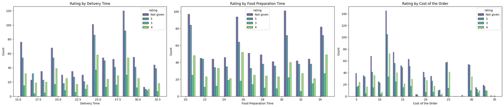

```python
plt.figure(figsize=(25, 10))

# Delivery Time Plot
plt.subplot(2,3,1)
sns.histplot(
    data=df,
    x='delivery_time',
    hue='rating',
    multiple='dodge',
    shrink=0.6,
    palette="viridis"
)

plt.title("Rating by Delivery Time")
plt.xlabel("Delivery Time")
plt.ylabel("Count")

# Food Preparation Time Plot
plt.subplot(2,3,2)
sns.histplot(
    data=df,
    x='food_preparation_time',
    hue='rating',
    multiple='dodge',
    shrink=0.6,
    palette="viridis"
)

plt.title("Rating by Food Preparation Time")
plt.xlabel("Food Preparation Time")
plt.ylabel("Count")

# Cost of the Order Plot
plt.subplot(2,3,3)
sns.histplot(
    data=df,
    x='cost_of_the_order',
    hue='rating',
    multiple='dodge',
    shrink=0.6,
    palette="viridis"
)

plt.title("Rating by Cost of the Order")
plt.xlabel("Cost of the Order")
plt.ylabel("Count")


# Showing the plots
plt.tight_layout()
plt.show()
```

- If we check the **Food Prepration Time**, it seems we have **4** different area that we can check more, also it is **same** for **Delivery Time**
- For **Cost of the Order** there is high demand between **10** to **17** dollars that we can analys them.
- Across all three factors (delivery time, preparation time, and cost), a significant proportion of customers do not leave ratings, especially around common values like **28** minutes for **delivery**, **31** minutes for **preparation**, and **$12** for **cost**.
- When ratings are provided, positive ratings (**5** and **4**) are generally associated with moderate delivery and preparation times and lower costs.
- This data could be used to optimize service elements such as maintaining delivery and preparation times within preferred ranges and managing pricing to encourage positive customer feedback.

Now let's deep dive into **rating** vs **top 10 customers** in giving ratings

```python
# Group data by customer_iod and then count their orders
top_users = df.groupby('customer_id').count()['order_id'].sort_values(ascending=False).head(20)
print('top users by highest order rate: \n',top_users)
print('\n')

# Find top users with the highest Not given rating
no_rating_condition = df['rating'] == 'Not given'
top_no_rating_users = df[no_rating_condition].groupby('customer_id').count()['order_id'].sort_values(ascending=False).head(10)
print('top users by highest order and no given rating: \n',top_no_rating_users)
print('\n')

# Find top users with the highest given rating
rating_condition = df['rating'] != 'Not given'
top_rating_users = df[rating_condition].groupby('customer_id').count()['order_id'].sort_values(ascending=False).head(10)
print('top users by highest order and given rating: \n',top_rating_users)
```

```
top users by highest order rate:
 customer_id
52832     13
47440     10
83287      9
250494     8
82041      7
276192     7
65009      7
259341     7
97079      6
107909     6
275689     6
97991      6
60052      6
```

[output cut: 38 more lines]

```python
# Create a DataFrame for furthor visualizations
top_users_index = top_users.index
top_users_df = df[df['customer_id'].isin(top_users_index)]
top_users_df.loc[:,'customer_id'] = top_users_df.loc[:,'customer_id'].astype(str)
```

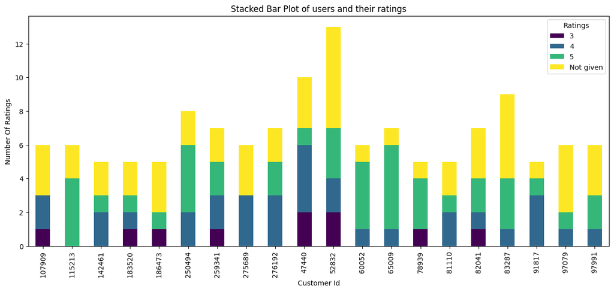

```python
# Stacked Bar Plot of users and their ratings
crosstab = pd.crosstab(top_users_df['customer_id'], top_users_df['rating'])
crosstab.plot(kind='bar', stacked=True, figsize=(15, 6), colormap='viridis')
plt.title('Stacked Bar Plot of users and their ratings')
plt.xlabel('Customer Id')
plt.ylabel('Number Of Ratings')
plt.legend(title='Ratings');
```

- As we can see there are users that give the ratings for all categories, and there are users who skip some ratings.
- This plot can help to identifying groups that are more or less likely to give certain types of ratings

Here we wanna check **rating** vs **cuisine type**

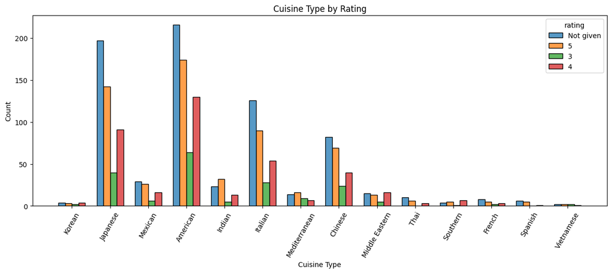

```python
plt.figure(figsize=(15, 5))
sns.histplot(
    data=df,
    x='cuisine_type',
    hue='rating',
    multiple='dodge',
    shrink=0.7
)

plt.title("Cuisine Type by Rating")
plt.xlabel("Cuisine Type")
plt.ylabel("Count")
plt.xticks(rotation=60)
plt.show()
```

- The plot suggests that certain cuisines, especially Japanese and American, are highly popular among customers, with a tendency for positive ratings when customers do choose to rate.
- The high “Not given” count across popular cuisines implies that many users engage with these cuisines without leaving feedback, which might indicate areas to encourage more customer participation in ratings.

#### Let's check the **cuisine type** and **day of the week**

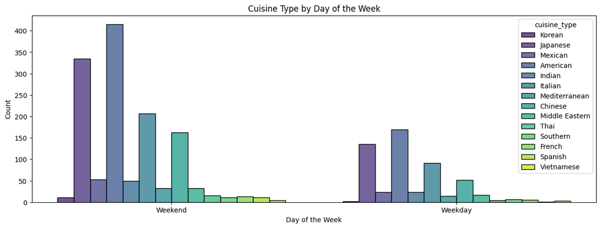

```python
plt.figure(figsize=(15, 5))
sns.histplot(
    data=df,
    x='day_of_the_week',
    hue='cuisine_type',
    multiple='dodge',
    shrink=0.8,
    palette="viridis"
)

plt.title("Cuisine Type by Day of the Week")
plt.xlabel("Day of the Week")
plt.ylabel("Count")
plt.show()
```

- The data reveals a clear preference for certain cuisines, particularly on weekends, where customers are likely exploring more options and choosing popular cuisines like **Italian**, **American**, and **Japanese**.
- The weekday choices are fewer and concentrated in specific cuisines, which could indicate a preference for familiar or convenient options during the workweek.
- Cuisines like **Southern**, **French**, **Spanish**, **Thai**, **Korean**, and **Vietnamese** have very low counts both on weekends and weekdays, indicating these are less commonly selected by customers.
- This information can be valuable for planning **promotions**, adjusting menu options, or targeting specific customer groups on different days.

#### Let's have a look for relationship between **day of the week** and **delivery time**

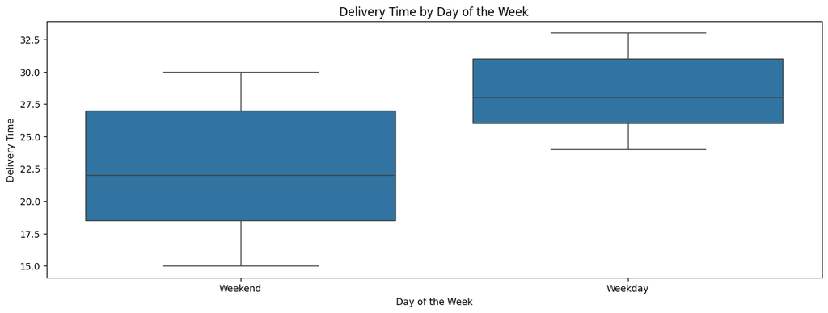

```python
plt.figure(figsize=(15, 5))
sns.boxplot(
    data=df,
    x='day_of_the_week',
    y='delivery_time'
)

plt.title("Delivery Time by Day of the Week")
plt.xlabel("Day of the Week")
plt.ylabel("Delivery Time")
plt.show()
```

### **Question 13:** The company wants to provide a promotional offer in the advertisement of the restaurants. The condition to get the offer is that the restaurants must have a rating count of more than 50 and the average rating should be greater than 4. Find the restaurants fulfilling the criteria to get the promotional offer. [3 marks]

```python
# Copy the data and convert rating from string to number
df_promo = df.copy()
df_promo['rating'] = pd.to_numeric(df_promo['rating'], errors='coerce')

# Group the resturand and apply count and mean function on the rating to have a new dataframe
restaurant_ratings = df_promo.groupby('restaurant_name')['rating'].agg(['count', 'mean'])

# apply conditions
promotional_restaurants = restaurant_ratings[(restaurant_ratings['count'] > 50) & (restaurant_ratings['mean'] > 4)]

print(promotional_restaurants)
```

```
                           count  mean
restaurant_name
Blue Ribbon Fried Chicken     64 4.328
Blue Ribbon Sushi             73 4.219
Shake Shack                  133 4.278
The Meatball Shop             84 4.512
```

#### Observations:

As we have 2 different conditions, we can use agg function, and in the result we can apply our conditions There are 4 restaurants:

- Blue Ribbon Fried Chicken
- Blue Ribbon Sushi
- Shake Shack
- The Meatball Shop

### **Question 14:** The company charges the restaurant 25% on the orders having cost greater than 20 dollars and 15% on the orders having cost greater than 5 dollars. Find the net revenue generated by the company across all orders. [3 marks]

```python
# Find the order costs more than 20 and apply the charge on sum of them
revenue_upper_20 = df[df['cost_of_the_order'] > 20]['cost_of_the_order'].sum() * 0.25

# Find the order costs betweeen 5 and 20 apply the charge on sum of them
df_less_20 = df[df['cost_of_the_order'] <= 20]
df_less_20_upper_5 = df_less_20[df_less_20['cost_of_the_order'] > 5]
revenue_5 = df_less_20_upper_5['cost_of_the_order'].sum() * 0.15

# Calculate the total revenue
total_revenue = revenue_upper_20 + revenue_5

print('The net revenue generated by the company across all orders is: ',total_revenue)
```

```
The net revenue generated by the company across all orders is:  6166.303
```

### **Question 15:** The company wants to analyze the total time required to deliver the food. What percentage of orders take more than 60 minutes to get delivered from the time the order is placed? (The food has to be prepared and then delivered.) [2 marks]

**NOTE:**

I already created this culumn for analysis.

```python
condition = df['total_time'] > 60

# Find the number of orders for more than 60 minutes prepration + delivery
more_60 = df[condition]['order_id'].count()

percentage_of_orders_more_60 = (more_60 / number_of_all_orders) * 100

print(f'Percentage of orders take more than 60 minutes to prepare and deliver: {round(percentage_of_orders_more_60,2)}%')
```

```
Percentage of orders take more than 60 minutes to prepare and deliver: 10.54%
```

### **Question 16:** The company wants to analyze the delivery time of the orders on weekdays and weekends. How does the mean delivery time vary during weekdays and weekends? [2 marks]

```python
# Group the data by day of the week and then calculate the mean of delivery time
df.groupby('day_of_the_week')['delivery_time'].mean()
```

| day_of_the_week | delivery_time |
| --- | --- |
| Weekday | 28.340 |
| Weekend | 22.470 |

**dtype:** float64

#### Observations:

The mean shows on average, orders on weekends deliver faster that weekdays

### Conclusion and Recommendations

### **Question 17:** What are your conclusions from the analysis? What recommendations would you like to share to help improve the business? (You can use cuisine type and feedback ratings to drive your business recommendations.) [6 marks]

#### Conclusions:

**Ratings**

- **Lack of Clear Pattern:** There is no clear pattern between users and the ratings they give. The only notable observation is that the ratings are above 3, suggesting that users may choose not to rate foods they did not enjoy.
- **Missing Ratings in Certain Cuisines:** Some types of cuisine have a high number of missing ratings.
- **Restaurants Without Ratings:** There are restaurants that do not have any ratings at all, and the number of orders for them is low.
- **Order Cost vs. Ratings:** Higher-rated orders (ratings 4 and 5) tend to have a wide range of order costs, but there is no strong indication that cost directly influences ratings. Orders with lower ratings are spread across various cost ranges, indicating that other factors likely play a significant role in customer satisfaction.

**Cuisine Type**

- **Most Popular Cuisine:** The most popular cuisine is American food.
- **Cuisine Type and Preparation Time:** There is no relationship between cuisine type and food preparation time.

**Delivery and Preparation Time**

**Order Volume Variations**

- **Variation Across Weekdays and Weekends:** There is variation in order volume across weekdays and weekends, with busier days affecting order flow.

**Insights into “Not Given” Ratings**

- **Restaurants with High “Not Given” Ratings:**

Certain restaurants, such as Shake Shack, The Meatball Shop, and Blue Ribbon Sushi, have significantly higher counts of “Not given” ratings. These restaurants may benefit from targeted efforts to encourage feedback, perhaps through incentives or follow-up reminders.

- **Cuisine Types with High “Not Given” Ratings:**

American, Japanese, and Italian cuisines have the most “Not given” ratings, suggesting a possible trend among customers ordering these cuisines to skip feedback. Highlighting the importance of reviews for these cuisine types could improve engagement.

- **Customers Frequently Giving “Not Given” Ratings:**

A few customers appear to consistently leave “Not given” ratings. Identifying these customers and possibly offering loyalty rewards or feedback incentives could encourage them to participate more actively in rating.

#### Recommendations:

1. **Enhance Customer Feedback:**

   Encourage customers to provide ratings, as a large portion of orders lacks feedback. This information could guide targeted improvements.
2. **Incentivize Feedback for Certain Restaurants and Cuisines:**

   Target restaurants with higher “Not given” ratings by offering discounts or loyalty points for reviews to enhance engagement.
3. **Create Feedback Incentives for Repeat Non-Raters:**

   Implement a reward system for customers who consistently provide ratings, especially those who typically skip feedback, to encourage more consistent reviews.
4. **Improve Feedback Request Timing:**

   Test different timings for feedback requests, such as sending reminders a few hours after delivery for popular cuisines or top restaurants, to capture more customer experiences.
5. **Optimize Weekend Operations:**

   Given the variance in delivery times on weekends, focusing on efficiency or managing order capacity on these days could enhance the customer experience.
6. **Cuisine-Based Promotions:**

   Popular cuisines could be highlighted in promotions, and targeted discounts or loyalty incentives could help drive up order frequency for less popular cuisines.
7. **Focus on Cuisine Types with Higher Variability in Ratings:**

   Some cuisine types show mixed ratings. Focusing on these areas to improve consistency can enhance customer satisfaction.
8. **Improve Efficiency in Delivery and Preparation:**

   Addressing bottlenecks to reduce high preparation times could lead to faster deliveries, enhancing customer satisfaction.
9. **Highlight Popular Cuisines on Key Days:**

   Given the variation in order volume across weekdays and weekends, promote popular cuisines on busier days to optimize order flow and ensure high customer engagement during peak times.

### Convert to HTML

```python
!jupyter nbconvert --to html "/content/drive/MyDrive/Colab Notebooks/University Case Studies/Project 1/Learner_Notebook_Full_Code.ipynb";
```

[output not shown]